# College Major Analysis

Shubhendu Dash

17/07/2020

# Regression Models:

The goal of the course is use regression analysis as tool to understand your data.

To achieve this objective, the course gives the tools to understand regressions, from the simple and practical linear model, to the glm, focussing on binary outcomes (logit) and count data (poisson).

## Optional Data Analysis Project:

This analysis is part of the optional quiz, to understand how students understand and work with data.

## A codebook for the dataset is given below:

1. rank: Rank by median earnings
2. major_code: Major code
3. major: Major description
4. major_category: Category of major
5. total: Total number of people with major
6. sample_size: Sample size of full-time, year-round individuals used for income/earnings estimates: p25th, median, p75th
7. p25th: 25th percentile of earnings
8. median: Median earnings of full-time, year-round workers
9. p75th: 75th percentile of earnings
10. perc_men: % men with major (out of total)
11. perc_women: % women with major (out of total)
12. perc_employed: % employed (out of total)
13. perc_employed_fulltime: % employed 35 hours or more (out of employed)
14. perc_employed_parttime: % employed less than 35 hours (out of employed)
15. perc_employed_fulltime_yearround: % employed at least 50 weeks and at least 35 hours (out of employed and full-time)
16. perc_unemployed: % unemployed (out of employed)
17. perc_college_jobs: % with job requiring a college degree (out of employed)
18. perc_non_college_jobs: % with job not requiring a college degree (out of employed)
19. perc_low_wage_jobs: % in low-wage service jobs (out of total)

## Data Analysis Process Starts:

1. Installing required packages.

   ```
    1.1 To get started, start a new R/RStudio session with a clean workspace. To do this in R, you can use the q() function to quit, then reopen R. The easiest way to do this in RStudio is to quit RStudio entirely and reopen it. After you have started a new session, run the following commands. This will load a data.frame called college for you to work with.
   ```

```r
#This will load a data.frame called college for you to work with.

#install.packages("devtools")
#devtools::install_github("jhudsl/collegeIncome", force = TRUE)
library(collegeIncome)
data(college)

#Next download and install the matahari R package with the following commands.

#devtools::install_github("jhudsl/matahari", force = TRUE)
library(matahari)
dance_start(value = FALSE, contents = FALSE)
```

2. Calling required packages from the library.

```r
library(ggplot2)
library(dplyr)
library(GGally)
```

3. Getting into the Analysis.

```r
#Initial phase of data.frame analysis.

dim(college)
```

```
## [1] 173  19
```

```r
str(college)
```

```
## 'data.frame':    173 obs. of  19 variables:
##  $ rank                            : int  1 2 3 4 5 6 7 8 9 10 ...
##  $ major_code                      : int  2419 2416 2415 2417 2405 2418 6202 5001 2414 2408 ...
##  $ major                           : chr  "Petroleum Engineering" "Mining And Mineral Engineering" "Metallurgical Engineering" "Naval Architecture And Marine Engineering" ...
##  $ major_category                  : chr  "Engineering" "Engineering" "Engineering" "Engineering" ...
##  $ total                           : int  2339 756 856 1258 32260 2573 3777 1792 91227 81527 ...
##  $ sample_size                     : int  36 7 3 16 289 17 51 10 1029 631 ...
##  $ perc_women                      : num  0.911 0.515 0.594 0.652 0.418 ...
##  $ p25th                           : num  25000 26000 26700 26000 31500 23000 32500 37900 29200 23000 ...
##  $ median                          : num  40000 37000 45000 35000 62000 44700 45000 57000 36000 32200 ...
##  $ p75th                           : num  50000 40000 60000 45000 109000 50000 58000 67000 46000 47100 ...
##  $ perc_men                        : num  0.0891 0.4846 0.4058 0.3479 0.5821 ...
##  $ perc_employed                   : num  0.912 0.798 0.787 0.847 0.852 ...
##  $ perc_employed_fulltime          : num  0.921 0.711 0.883 0.937 0.809 ...
##  $ perc_employed_parttime          : num  0.177 0.362 0.339 0.167 0.402 ...
##  $ perc_employed_fulltime_yearround: num  0.77 0.709 0.774 0.653 0.685 ...
##  $ perc_unemployed                 : num  0.0885 0.2019 0.2128 0.1534 0.1484 ...
##  $ perc_college_jobs               : num  0.67 0.387 0.729 0.246 0.587 ...
##  $ perc_non_college_jobs           : num  0.182 0.516 0.176 0.411 0.386 ...
##  $ perc_low_wage_jobs              : num  0.0554 0.2156 0.0301 0.0432 0.118 ...
```

```
    3.1 How's the distribution of fulltime employment? Is there a gender difference?
```

```r
g <- ggplot(aes(perc_employed_fulltime_yearround, major_category, colour=perc_women), data=college)
g <- g + geom_point(size=2) + labs(x="Percentage Employed Fulltime Yearround", y="Major Category")
g <- g + scale_colour_gradient(name="Percentage of Women")
```

```
    3.2 Is there a difference in the median of earnings?
```

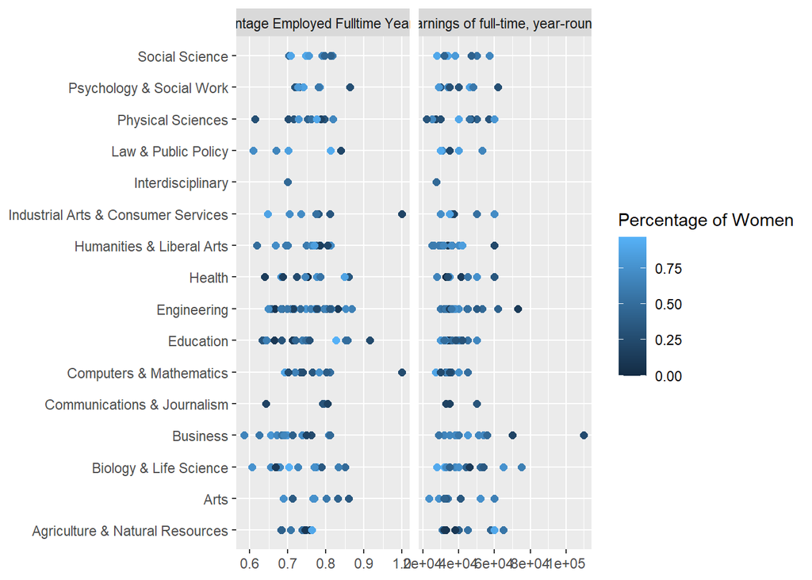

```
    3.3 Looking median, 25th and 75th quintile of earnings.
```

```r
h <- ggplot(aes(median, major_category, colour=perc_women), data=college)
h <- h + geom_point(size=2) + labs(x="Median earnings of full-time, year-round workers", y="Major Category") + scale_colour_gradient(name="Percentage of Women")
ggmatrix(list(g, h), ncol=2, nrow=1, legend=grab_legend(g), xAxisLabels = c("Percentage Employed Fulltime Yearround","Median earnings of full-time, year-round workers" ))
```

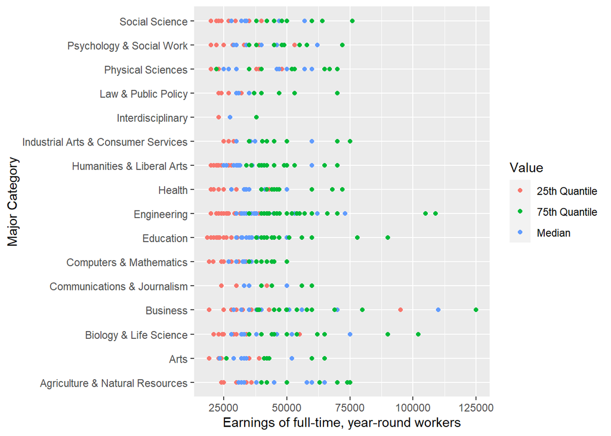

```
    3.4 Investigating these majors further.
```

```r
p25th <- data.frame(Earnings = college$p25th, Major_category = college$major_category, Major = college$major, Value="25th Quantile")
median <- data.frame(Earnings = college$median, Major_category = college$major_category, Major = college$major, Value="Median")
p75th <- data.frame(Earnings = college$p75th, Major_category = college$major_category, Major = college$major, Value="75th Quantile")
earnings <- rbind(p25th, median, p75th)
m <- ggplot(aes(Earnings, Major_category), data=earnings)
m <- m + geom_point(aes(colour=Value)) + labs(x="Earnings of full-time, year-round workers", y="Major Category")
m #The higher earnings are Engineering, Education, Business and Biology & Life Science
```

[figure not shown]

```
    3.5 Looking at all the correlations.
```

```r
big4 <- filter(earnings, Major_category=="Engineering"| Major_category=="Education"| Major_category=="Business" | Major_category=="Biology & Life Science")
l <- ggplot(aes(Earnings, Major), data = big4) + facet_grid(Major_category ~ .)
l <- l + geom_point(aes(colour = Value)) + labs(x="Earnings of full-time, year-round workers", y=NULL)
l
```

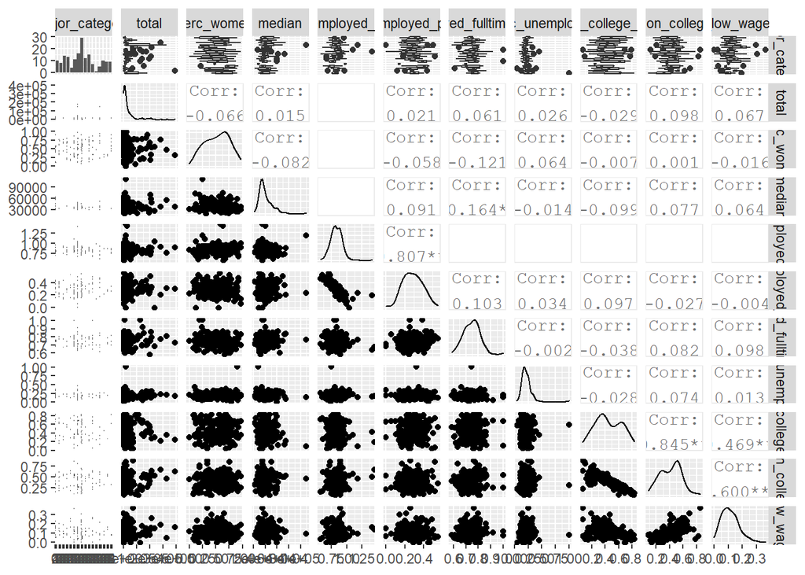

```
    3.6 Regressions.
```

```r
all <- ggpairs(data = select(college, c(major_category, total, perc_women, median, perc_employed_fulltime:perc_low_wage_jobs)), cardinality_threshold = 17)
all
```

```r
fit <- lm(median ~ factor(major_category), data=college)
summary(fit)
```

```
##
## Call:
## lm(formula = median ~ factor(major_category), data = college)
##
## Residuals:
##    Min     1Q Median     3Q    Max
## -20154  -6800  -2893   4833  60846
##
## Coefficients:
##                                                           Estimate Std. Error
## (Intercept)                                                43500.0     3590.8
## factor(major_category)Arts                                 -5450.0     5386.2
## factor(major_category)Biology & Life Science                 364.3     4701.5
## factor(major_category)Business                              5653.8     4776.2
## factor(major_category)Communications & Journalism          -1500.0     6717.8
## factor(major_category)Computers & Mathematics              -8781.8     4961.4
## factor(major_category)Education                            -5562.5     4577.4
## factor(major_category)Engineering                          -3106.9     4164.2
## factor(major_category)Health                               -3183.3     4862.0
## factor(major_category)Humanities & Liberal Arts            -8333.3     4635.7
## factor(major_category)Industrial Arts & Consumer Services  -3071.4     5595.9
## factor(major_category)Interdisciplinary                   -16000.0    11909.4
## factor(major_category)Law & Public Policy                  -5700.0     6219.5
## factor(major_category)Physical Sciences                    -3100.0     5078.2
## factor(major_category)Psychology & Social Work             -3611.1     5217.3
## factor(major_category)Social Science                       -4433.3     5217.3
##                                                           t value Pr(>|t|)
## (Intercept)                                                12.114   <2e-16 ***
## factor(major_category)Arts                                 -1.012   0.3132
## factor(major_category)Biology & Life Science                0.077   0.9383
## factor(major_category)Business                              1.184   0.2383
## factor(major_category)Communications & Journalism          -0.223   0.8236
## factor(major_category)Computers & Mathematics              -1.770   0.0787 .
## factor(major_category)Education                            -1.215   0.2261
## factor(major_category)Engineering                          -0.746   0.4567
## factor(major_category)Health                               -0.655   0.5136
## factor(major_category)Humanities & Liberal Arts            -1.798   0.0742 .
## factor(major_category)Industrial Arts & Consumer Services  -0.549   0.5839
## factor(major_category)Interdisciplinary                    -1.343   0.1811
## factor(major_category)Law & Public Policy                  -0.916   0.3608
## factor(major_category)Physical Sciences                    -0.610   0.5424
## factor(major_category)Psychology & Social Work             -0.692   0.4899
## factor(major_category)Social Science                       -0.850   0.3968
## ---
## Signif. codes:  0 '***' 0.001 '**' 0.01 '*' 0.05 '.' 0.1 ' ' 1
##
## Residual standard error: 11360 on 157 degrees of freedom
## Multiple R-squared:  0.1054, Adjusted R-squared:  0.01995
## F-statistic: 1.233 on 15 and 157 DF,  p-value: 0.2522
```

```r
#The major categories weren't significant

fit2 <- lm(median ~ factor(major_category) + perc_women, data = college)
anova(fit, fit2)
```

```
## Analysis of Variance Table
##
## Model 1: median ~ factor(major_category)
## Model 2: median ~ factor(major_category) + perc_women
##   Res.Df        RSS Df Sum of Sq      F Pr(>F)
## 1    157 2.0244e+10
## 2    156 2.0034e+10  1 210042153 1.6356 0.2028
```

```r
#Still not able to reject the null hypothesis, thus the regressors are not significant

fit3 <- lm(median ~ perc_women, data = college)
anova(fit3, fit2)
```

```
## Analysis of Variance Table
##
## Model 1: median ~ perc_women
## Model 2: median ~ factor(major_category) + perc_women
##   Res.Df        RSS Df  Sum of Sq      F Pr(>F)
## 1    171 2.2476e+10
## 2    156 2.0034e+10 15 2442945925 1.2682 0.2284
```

```r
fit4 <- lm(median ~ factor(major_category)*perc_women, data=college)
summary(fit4)
```

```
##
## Call:
## lm(formula = median ~ factor(major_category) * perc_women, data = college)
##
## Residuals:
##    Min     1Q Median     3Q    Max
## -21598  -6157  -2079   5049  36281
##
## Coefficients: (1 not defined because of singularities)
##                                                                      Estimate
## (Intercept)                                                             30716
## factor(major_category)Arts                                               5000
## factor(major_category)Biology & Life Science                            23768
## factor(major_category)Business                                          61626
## factor(major_category)Communications & Journalism                       -3044
## factor(major_category)Computers & Mathematics                            4857
## factor(major_category)Education                                          6696
## factor(major_category)Engineering                                       18145
## factor(major_category)Health                                             7188
## factor(major_category)Humanities & Liberal Arts                          9010
## factor(major_category)Industrial Arts & Consumer Services                6043
## factor(major_category)Interdisciplinary                                -17641
## factor(major_category)Law & Public Policy                                8560
## factor(major_category)Physical Sciences                                  3291
## factor(major_category)Psychology & Social Work                          12387
## factor(major_category)Social Science                                    17061
## perc_women                                                              30276
## factor(major_category)Arts:perc_women                                  -26241
## factor(major_category)Biology & Life Science:perc_women                -47515
## factor(major_category)Business:perc_women                             -105012
## factor(major_category)Communications & Journalism:perc_women            17002
## factor(major_category)Computers & Mathematics:perc_women               -32049
## factor(major_category)Education:perc_women                             -29222
## factor(major_category)Engineering:perc_women                           -46980
## factor(major_category)Health:perc_women                                -24854
## factor(major_category)Humanities & Liberal Arts:perc_women             -38658
## factor(major_category)Industrial Arts & Consumer Services:perc_women   -23409
## factor(major_category)Interdisciplinary:perc_women                         NA
## factor(major_category)Law & Public Policy:perc_women                   -32447
## factor(major_category)Physical Sciences:perc_women                     -16748
```

[output cut: 125 more lines]

```
## factor(major_category)Engineering:perc_women                         **
## factor(major_category)Health:perc_women
## factor(major_category)Humanities & Liberal Arts:perc_women           *
## factor(major_category)Industrial Arts & Consumer Services:perc_women
## factor(major_category)Interdisciplinary:perc_women
## factor(major_category)Law & Public Policy:perc_women
## factor(major_category)Physical Sciences:perc_women
## factor(major_category)Psychology & Social Work:perc_women            .
## factor(major_category)Social Science:perc_women                      .
## ---
## Signif. codes:  0 '***' 0.001 '**' 0.01 '*' 0.05 '.' 0.1 ' ' 1
##
## Residual standard error: 10670 on 142 degrees of freedom
## Multiple R-squared:  0.2851, Adjusted R-squared:  0.134
## F-statistic: 1.887 on 30 and 142 DF,  p-value: 0.007361
```

```r
#Now there are some very significant coef
anova(fit, fit4)
```

```
## Analysis of Variance Table
##
## Model 1: median ~ factor(major_category)
## Model 2: median ~ factor(major_category) * perc_women
##   Res.Df        RSS Df  Sum of Sq      F   Pr(>F)
## 1    157 2.0244e+10
## 2    142 1.6178e+10 15 4065245219 2.3788 0.004338 **
## ---
## Signif. codes:  0 '***' 0.001 '**' 0.01 '*' 0.05 '.' 0.1 ' ' 1
```